# Rarepair Rumble

darthaline

3 Aug 2020

# About

This is a document detailing analysis of [TDP Rarepair Rumble 2020](https://tdp-shipping-dock.tumblr.com/rarepair-rumble), starting from Round 2CD. This event is hosted by Inga, who kindly gave me access to the resposes data.

## Round 2CD

In this round I did’t have information about where each individual response came from, so the source value is estimated based on the poll posting date on each individual platform. The dates were determined by the creation dates of the screenshots Inga provided.

```r
data <- read.csv2 (file.path('data','Rarepair Rumble Round 2CD (Responses) - Form responses 1.csv'), header = TRUE, sep=',')
data <- sapply(data, as.character)
data[data == ''] <- "_choose not to vote"
data[data == "I don't want to vote for either of these ships"] <- "_choose not to vote"
data <- data.frame(data)

data$source <- 'Discord'
data[13:35,]$source <- 'Tumblr & Ao3'
data[36:51,]$source <- 'Twitter & Reddit'
data[52:69,]$source <- 'Instagram'

data$Timestamp <- parse_date_time2(as.character(data$Timestamp), orders = "%d/%m/%Y %H:%M:%S")
data$day <- as.Date(data$Timestamp)
```

```r
plot_data_column <- function (data, column, legendPosition) {
    ggplot(data, aes_string(x = column)) +
    geom_bar(aes(col=source, fill=source), alpha = 0.5)+
    scale_colour_manual(values = custompalette)+
    scale_fill_manual(values = custompalette) +
    theme_half_open() +
    background_grid() +
    theme(axis.text.x = element_text(angle = 90, vjust = 0.5, hjust=1),
          axis.title.y=element_blank(),
          axis.title.x=element_blank(),
          legend.position = legendPosition)
}

plot_data_column_title <- function (data, column, legendPosition) {
    ggplot(data, aes_string(x = column)) +
    geom_bar(aes(col=source, fill=source), alpha = 0.5)+
    scale_colour_manual(values = custompalette)+
    scale_fill_manual(values = custompalette,drop=FALSE) +
    scale_x_discrete(drop=FALSE)+
    theme_half_open() +
    background_grid() +
    theme(axis.text.x = element_text(angle = 90, vjust = 0.5, hjust=1),
          axis.title.y=element_blank(),
          axis.title.x=element_blank(),
          legend.position = legendPosition)+
    ggtitle(gsub('\\.', ' ', column))
}
```

### Distribution of platforms

Below is the distribution of answers from the platforms, but due to indirect method of measurement it should be taken with a grain of salt.

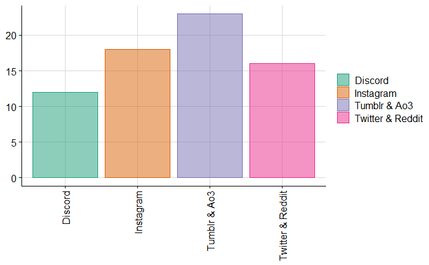

```r
sourceplot <- plot_data_column(data, colnames(data)[18], 'right') +
                       theme(legend.title=element_blank())
mylegend <- get_legend(sourceplot)
sourceplot
```

### Votes result

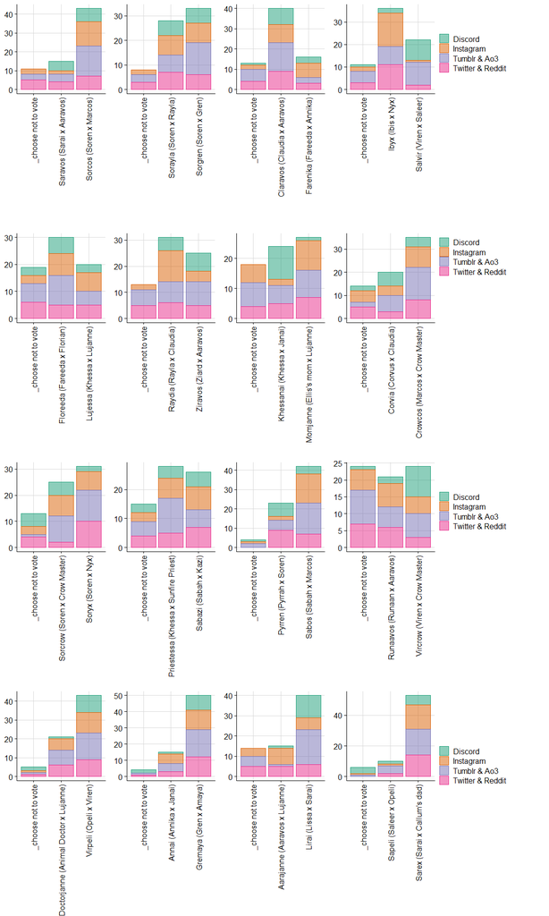

```r
myplots <- lapply(colnames(data)[2:17], plot_data_column, data = data, legendPosition = 'none')

plot_grid(plot_grid(plotlist = myplots, align='hv'),
          plot_grid(plotlist = rep(list(mylegend),4), nrow=4, rel_heights = c(1,3,2,3)),
          rel_widths = c(4,1),
          align='hv')
```

```r
rm(data, mylegend, myplots)
```

## Round 3

Round 3 and onwards included a question about where the poll was found, so we can take a precise look at each platform’s preferences.

```r
data <- read.csv2 (file.path('data','Rarepair Rumble Round 3.csv'), header = TRUE, sep=',')
data <- sapply(data, as.character)
data[,'Where.did.you.find.the.link.to.this.round.'][data[,'Where.did.you.find.the.link.to.this.round.'] == '']<- "No Source Provided"
data[data == "I don't want to vote for either of these ships"] <- "_choose not to vote"
data[data == ""] <- "_choose not to vote"
data[data == "Didn't see it on reddit so searched for it on Tumblr"] <- "Tumblr"
data <- data.frame(data)

titles <- colnames(data)
titles[titles == "Where.did.you.find.the.link.to.this.round."] <- "source"
titles <- sub("X.", "", titles)
titles <- sub("[[:digit:]]", "", titles)
titles <- sub("[[:digit:]]", "", titles)
titles <- sub(".vs.", "_vs_", titles)
titles <- sub("[[:punct:]]", "", titles)
titles <- sub("[[:punct:]]", "", titles)

colnames(data)<- titles

#data$Timestamp <- parse_date_time2(as.character(data$Timestamp), orders = "%d/%m/%Y %H:%M:%S")

rm(titles)
```

### Distribution of platforms

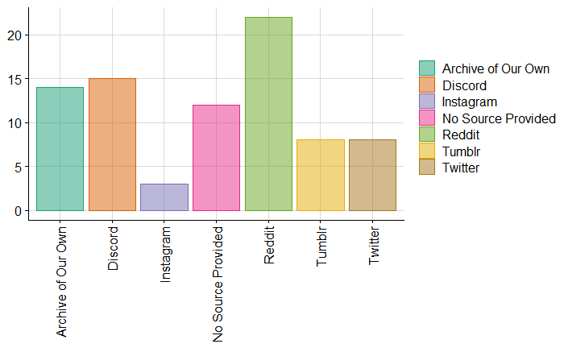

```r
sourceplot <- plot_data_column(data, colnames(data)[2], 'right') +
                       theme(legend.title=element_blank())
mylegend <- get_legend(sourceplot)
sourceplot
```

### Votes result

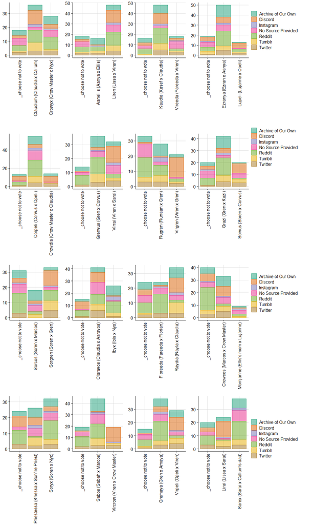

```r
myplots <- lapply(colnames(data)[3:18], plot_data_column, data = data, legendPosition = 'none')

plot_grid(plot_grid(plotlist = myplots, align='hv'),
          plot_grid(plotlist = rep(list(mylegend),4), nrow=4, rel_heights = c(1,3,2,3)),
          rel_widths = c(4,1),
          align='hv')
```

```r
rm(data, sourceplot, mylegend, myplots)
```

## Round 4

```r
data <- read.csv2 (file.path('data','Rarepair Rumble Round 4.csv'), header = TRUE, sep=',')
data <- sapply(data, as.character)
data[,'Where.did.you.find.the.link.to.this.round.'][data[,'Where.did.you.find.the.link.to.this.round.'] == '']<- "No Source Provided"
data[data == "I don't want to vote for either of these ships"] <- "_choose not to vote"
data[data == ""] <- "_choose not to vote"
data <- data.frame(data)

titles <- colnames(data)
titles[titles == "Where.did.you.find.the.link.to.this.round."] <- "source"
titles <- sub("X.", "", titles)
titles <- sub("[[:digit:]]", "", titles)
titles <- sub("[[:digit:]]", "", titles)
titles <- sub(".vs.", "_vs_", titles)
titles <- sub("[[:punct:]]", "", titles)
titles <- sub("[[:punct:]]", "", titles)

colnames(data)<- titles

rm(titles)
```

### Distribution of platforms

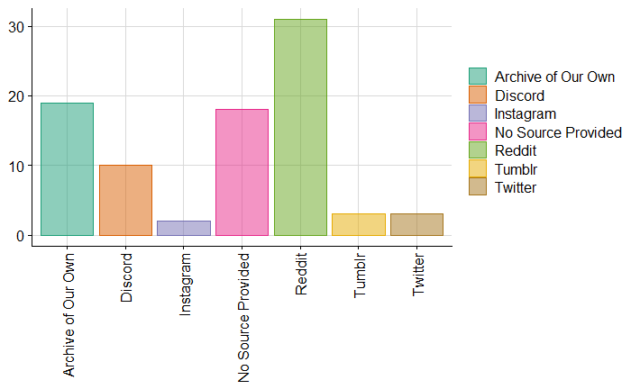

```r
sourceplot <- plot_data_column(data, colnames(data)[2], 'right') +
                       theme(legend.title=element_blank())
mylegend <- get_legend(sourceplot)
sourceplot
```

### Votes result

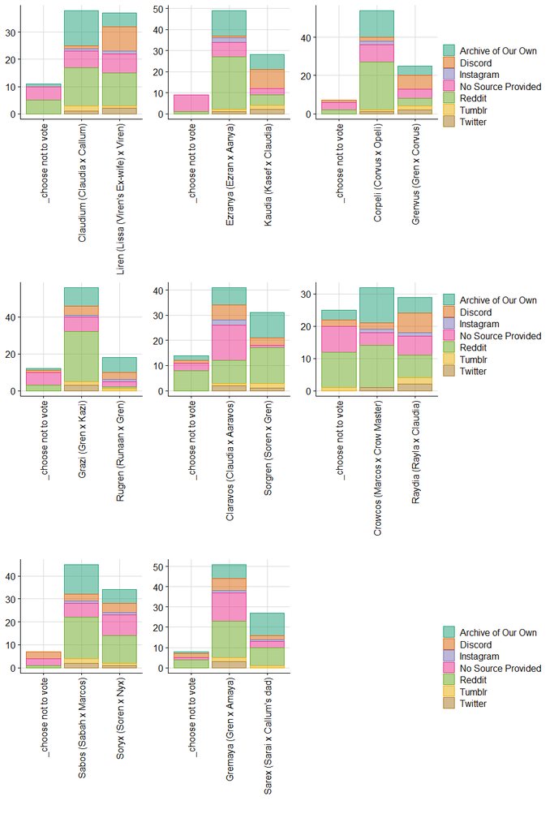

```r
myplots <- lapply(colnames(data)[3:10], plot_data_column, data = data, legendPosition = 'none')

plot_grid(plot_grid(plotlist = myplots, align='hv'),
          plot_grid(plotlist = rep(list(mylegend),3), nrow=3, rel_heights = c(1,2,2)),
          rel_widths = c(4,1),
          align='hv')
```

```r
rm(data, sourceplot, mylegend, myplots)
```

## Round 5

```r
data <- read.csv2 (file.path('data','RarePair Rumble Quarterfinal! (round 5).csv'), header = TRUE, sep=',')
dataActive <- data[2:10]
data <- data[c(1,2,11:14)]
data <- sapply(data, as.character)
data[,'Where.did.you.find.the.link.to.this.round.'][data[,'Where.did.you.find.the.link.to.this.round.'] == '']<- "No Source Provided"
data[data == "I don't want to vote for either of these ships"] <- "_choose not to vote"
data[data == ""] <- "_choose not to vote"
data <- data.frame(data)

titles <- colnames(data)
titles[titles == "Where.did.you.find.the.link.to.this.round."] <- "source"
titles <- sub("X.", "", titles)
titles <- sub("[[:digit:]]", "", titles)
titles <- sub("[[:digit:]]", "", titles)
titles <- sub(".vs.", "_vs_", titles)
titles <- sub("[[:punct:]]", "", titles)
titles <- sub("[[:punct:]]", "", titles)

colnames(data)<- titles

rm(titles)
```

```r
dataActive <- sapply(dataActive, as.character)
dataActive[,'Where.did.you.find.the.link.to.this.round.'][dataActive[,'Where.did.you.find.the.link.to.this.round.'] == '']<- "No Source Provided"
titles <- c("source",
            "Claudia x Callum",
            "Ezran x Aanya",
            "Corvus x Opeli",
            "Gren x Kazi",
            "Claudia x Aaravos",
            "Marcos x Crow Master",
            "Sabah x Marcos",
            "Gren x Amaya")
colnames(dataActive) <- titles

dataActive[dataActive == ""] <- "_choose not to vote"
dataActive <- data.frame(dataActive)

rm(titles)
```

### Distribution of platforms

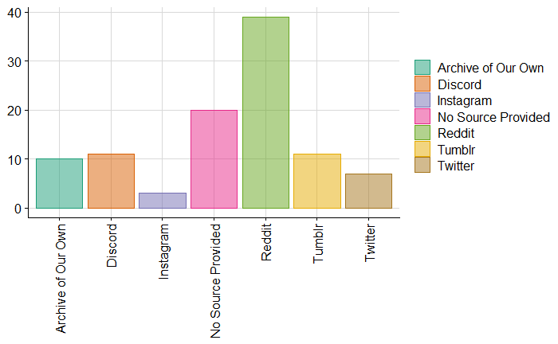

```r
sourceplot <- plot_data_column(data, colnames(data)[2], 'right') +
                       theme(legend.title=element_blank())
mylegend <- get_legend(sourceplot)
sourceplot
```

### Active shipping preferences

This round included a new kind of question, where people could indicate their preferences with regards to competing ships.

Most ships included here have a relatively small number of “active shippers”, compared to those who those who simply “like” the idea of them together.

It’s worth noting that “Crowcos (Marcos x Crow Master)” got the majority of votes in “no opinions” category, indicating, that, perhaps, it got to the top due to strong dislike of voters for ships competing against it, rather than its individual appeal.

Interestingly, “Clarvos (Claudia x Aaravos)”, which competed against “Crowcos (Marcos x Crow Master)” in this round, has majority of votes allocated towards “dislike” category. Despite that, it won with a margin of approximately 10 votes - most likely thanks to it’s active shippers, and a relatively high number of people who chose not to vote for either.

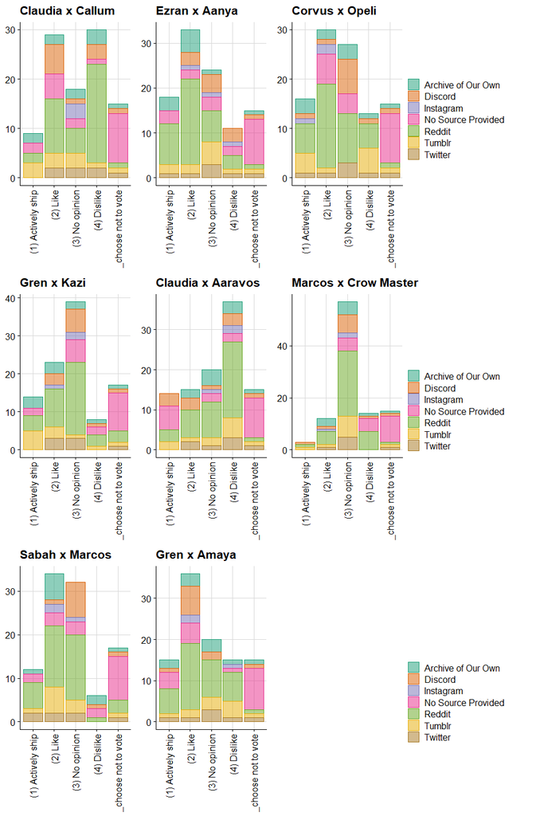

```r
myplots <- lapply(colnames(dataActive)[2:9], plot_data_column_title, data = dataActive, legendPosition = 'none')

plot_grid(plot_grid(plotlist = myplots, align='hv'),
          plot_grid(plotlist = rep(list(mylegend),3), nrow=3, rel_heights = c(2,3,2)),
          rel_widths = c(3,1),
          align='hv')
```

```r
#rm(dataActive, myplots)
```

### Votes result

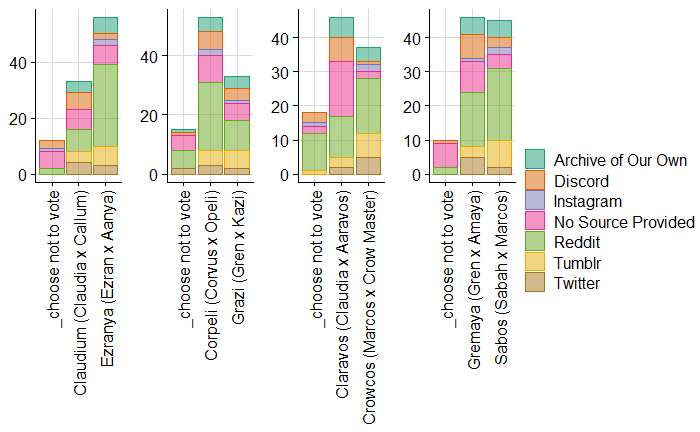

```r
myplots <- lapply(colnames(data)[3:6], plot_data_column, data = data, legendPosition = 'none')

plot_grid(plot_grid(plotlist = myplots, align='h', nrow=1),
          mylegend,
          rel_widths = c(3,1))
```

```r
rm(sourceplot, mylegend, myplots, data)
```

## Round 6

```r
data <- read.csv2 (file.path('data','RarePair Rumble Semifinal! (round 6).csv'), header = TRUE, sep=',', stringsAsFactors=FALSE)
data[2] [data[2] == ""] <- "No Source Provided"
dataActive <- data[c(2, grep('Actively.ship', colnames(data)))]
data <- data[-grep('Actively.ship', colnames(data))]
dataCompeting <- data[c(2, grep('Competing.for', colnames(data)))]
data <- data[-grep('Competing.for', colnames(data))]
#data <- sapply(data, as.character)
#data[,'Where.did.you.find.the.link.to.this.round.'][data[,'Where.did.you.find.the.link.to.this.round.'] == '']<- "No Source Provided"
data[data == "I don't want to vote for either of these ships"] <- "_choose not to vote"
data[data == ""] <- "_choose not to vote"

titles <- colnames(data)
titles[titles == "Where.did.you.find.the.link.to.this.round."] <- "source"
titles <- sub("X.", "", titles)
titles <- sub("[[:digit:]]", "", titles)
titles <- sub("[[:digit:]]", "", titles)
titles <- sub(".vs.", "_vs_", titles)
titles <- sub("\\..", "", titles)
colnames(data)<- titles

colnames(dataCompeting)<- c("source",
                            "Comp.124.vs.125",
                            "Comp.59.vs.60.vs.61",
                            "Comp.55.vs.56",
                            "Comp.39.vs.40",
                            "Comp.34.vs.35.vs.36",
                            "Comp.27.vs.28",
                            "Comp.22.vs.23")
dataCompeting$source <- as.character(dataCompeting$source)

dataCompeting <- sapply(dataCompeting, as.character)
dataCompeting[dataCompeting == "I don't want to vote for any of these ships"] <- "_choose not to vote"
dataCompeting[dataCompeting == "I don't want to vote for either of these ships"] <- "_choose not to vote"
dataCompeting[dataCompeting == ""] <- "_choose not to vote"

rm(titles)

dataActive <- sapply(dataActive, as.character)
titles <- c("source",
            "Soren x Ezran",
            "Villads x Viren",
            "Allen x Lujanne",
            "Khessa x Amaya",
            "Kasef x Soren",
            "Sarai x Aaravos",
            "Annika x Janai",
            "Aaravos x Lujanne",
            "Callum x Soren",
            "Fareeda x Neha",
            "Ziard x Aaravos",
            "Soren x Crow Master",
            "Fareeda x Viren",
            "Soren x Marcos",
            "Fareeda x Florian",
            "Lissa x Sarai")
colnames(dataActive) <- titles

dataActive[dataActive == ""] <- "_choose not to vote"
dataActive <- data.frame(dataActive)

rm(titles)
```

### Distribution of platforms

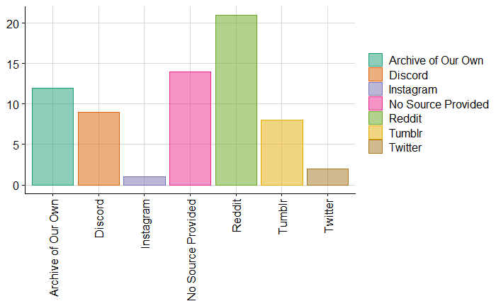

```r
sourceplot <- plot_data_column(data, colnames(data)[2], 'right') +
                       theme(legend.title=element_blank())
mylegend <- get_legend(sourceplot)
sourceplot
```

### Votes result

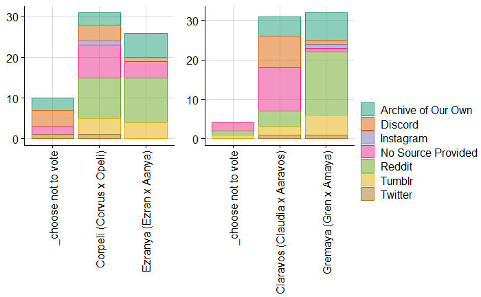

```r
myplots <- lapply(colnames(data)[3:4], plot_data_column, data = data, legendPosition = 'none')

plot_grid(plot_grid(plotlist = myplots, align='h', nrow=1),
          mylegend,
          rel_widths = c(3,1))
```

### Next shipping event participants

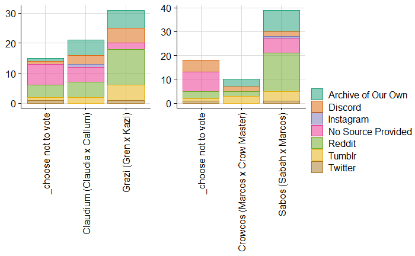

```r
myplots <- lapply(colnames(data)[5:6], plot_data_column, data = data, legendPosition = 'none')

plot_grid(plot_grid(plotlist = myplots, align='h', nrow=1),
          mylegend,
          rel_widths = c(3,1))
```

```r
rm(myplots, data)
```

### Active shipping tie-breakers

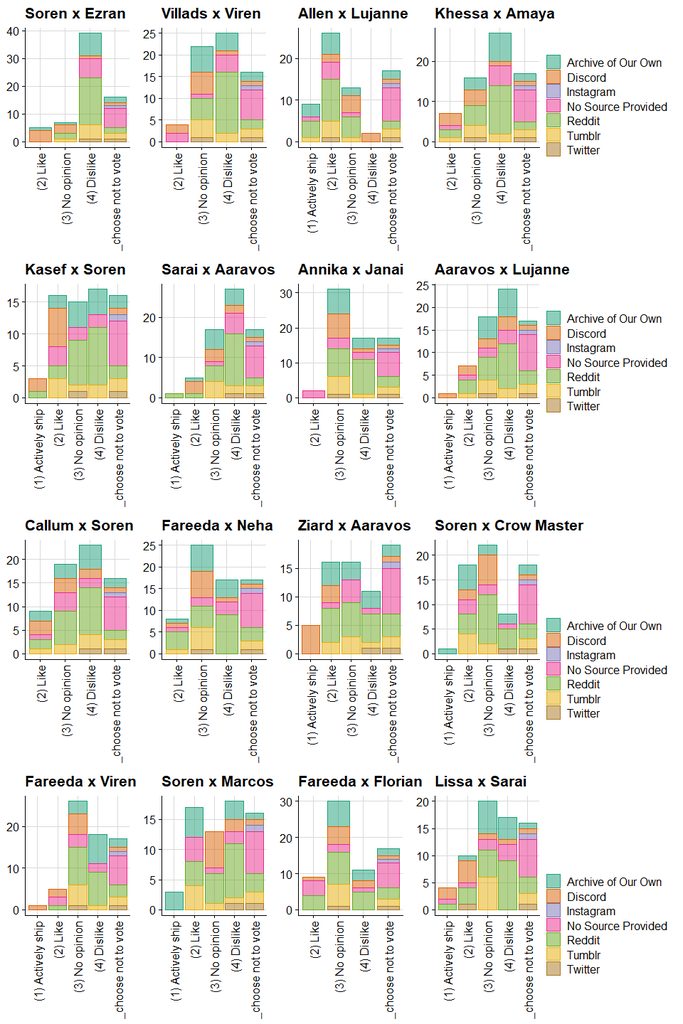

```r
myplots <- lapply(colnames(dataActive)[2:17], plot_data_column_title, data = dataActive, legendPosition = 'none')

plot_grid(plot_grid(plotlist = myplots, align='hv'),
          plot_grid(plotlist = rep(list(mylegend),4), nrow=4, rel_heights = c(2,3,3,2)),
          rel_widths = c(4,1),
          align='hv')
```

```r
#rm(dataActive, myplots)
```

### Order tie-breakers

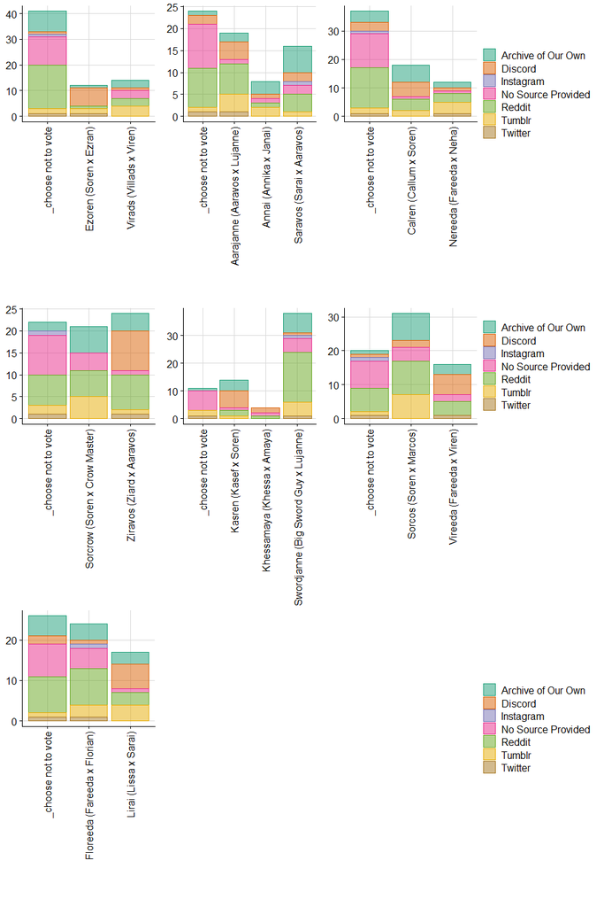

```r
dataCompeting <- as.data.frame(dataCompeting)
myplots <- lapply(colnames(dataCompeting)[2:8], plot_data_column, data = dataCompeting, legendPosition = 'none')

plot_grid(plot_grid(plotlist = myplots, align='hv'),
          plot_grid(plotlist = rep(list(mylegend),3), nrow=3, rel_heights = c(1,2,2)),
          rel_widths = c(4,1),
          align='hv')
```

## Round 7 (Final)

Only 2 ships competed in this round

```r
data <- read.csv2 (file.path('data','RarePair Rumble Final Round!7.csv'), header = TRUE, sep=',', stringsAsFactors=FALSE)
data[2] [data[2] == ""] <- "No Source Provided"
#data[data == "I don't want to vote for either of these ships"] <- "_choose not to vote"
data[data == ""] <- "_choose not to vote"

colnames(data) <- c("Timestamp", "source", "Winner")
```

### Distribution of platforms

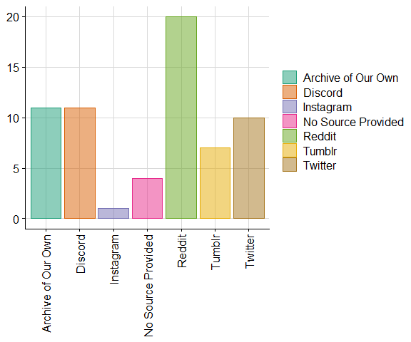

```r
sourceplot <- plot_data_column(data, colnames(data)[2], 'right') +
                       theme(legend.title=element_blank())
#mylegend <- get_legend(sourceplot)
sourceplot
```

### Votes result

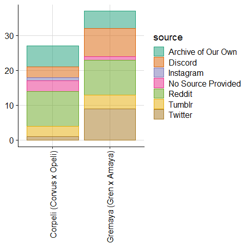

```r
myplots <- plot_data_column(data = data, column = colnames(data)[3], legendPosition = 'right')
myplots
```

# Other links

[Ao3 data analysis for The Dragon Prince (Cartoon)](https://darthaline.github.io/Ao3SearchAnalysis/fandoms/TDP/TDP_processing_notebook.nb.html)

If you enjoyed this analysis, please, consider [buying me a coffee](https://ko-fi.com/D1D8RIG5) or some other beverage.